# me20260303_figure_3D

Mathias

2026-03-03

#Aim When we conducted the hopping experiment of the 1xCBS_Fw_Sox2P insert from LP-116kb, we sorted some cells as clones and grew them out. We then mapped the integrations of those clones via Tagmentation and re-measured their fluorescence (Sox2::GFP, Sox2::mCherry and Sox2P::mTurq) by FACS. Here we want to match the mapped locations of clones with the corresponding fluorescence intensity to see location specific expression changes.

# Set-up

Load the libraries and set the parameters.

```r
# Load dependencies
library(GenomicRanges)
library(rtracklayer)
library(tidyverse)
```

```r
library(dtplyr)
library(dplyr)
library(tidyr)
library(ggbeeswarm)
library(ggplot2)
library(Biostrings)
library(stringr)
library(readr)
library(knitr)
library(RColorBrewer)
library(RcppRoll)
library(readxl)
library(plotly)
# library(flowCore)
import::from(flowCore, .except=c("filter")) #I don't load the whole flowCore and ggcyto libraries, because they overwrite dplyr's filter function :0
import::from(ggcyto, 'fortify_fs')
library(flowDensity)
library(cowplot)
split_string <- function(vect,sep,N1,N2=N1){
  library(stringr)
  sapply(vect, function(X){
    paste(str_split(X,sep)[[1]][N1:N2],collapse = sep)
  },USE.NAMES = F)
}
```

# Paths & parameters

```r
setwd("/DATA/usr/m.eder/GitHub/CBS_Sox2_manuscript/Figures/Figure_3/")

#datatag
datetag = paste0("ME",format(Sys.time(), '%Y%m%d'))

# Prepare output
output_dir <- paste0("/DATA/projects/CTCF_Sox2/Scripts/for_figures/Figure_3/analysis_Figure_3D_",datetag)
dir.create(output_dir, showWarnings = FALSE)
```

```r
library(knitr)
opts_chunk$set(fig.width = 20, fig.height = 8, cache = T,
               message = F, warning = F,
               dev=c('png', 'pdf'),
               fig.path = file.path(output_dir, "figures/"))
pdf.options(useDingbats = FALSE)
```

```r
# Location of enhancer / gene
enhancer <- GRanges(seqnames = "chr3",
                    ranges = IRanges(start = 34753415,
                                     end = 34766401),
                    strand = "*")

#gene based on mm10, ucsc browser, RefSeq annotation
gene <- GRanges(seqnames = "chr3",
                    ranges = IRanges(start = 34650405,
                                     end = 34652461),
                    strand = "+")

landingPad_23 <- GRanges(seqnames = "chr3",
                    ranges = IRanges(start = 34643960,
                                     end = 34643962),
                    strand = "+")

landingPad_8 <- GRanges(seqnames = "chr3",
                    ranges = IRanges(start = 34721183,
                                     end = 34721184),
                    strand = "+")


#CTCF sites based on our own mapping
# new analysis (based on mapping to mm10 only)
CTCF_mm10_new <- import.bed('/DATA/usr/v.franceschini/Workspaces/2024_01_MATHIAS_CTCF_PEAKS/VF240812_calling_CTCF_motifs_again/02_OUTPUTS/CTCF_sites/6764_2_ME_E2_CGATGT_S2_R1_001_peaks_motifs.bed')

#filtering:
CTCF_mm10.chr3 <- CTCF_mm10_new[seqnames(CTCF_mm10_new)== 'chr3']
# add the missing site after the SCR
CTCF_mm10.chr3_extra = sort(c(CTCF_mm10.chr3,
                         GRanges(seqnames = "chr3",
                                 IRanges(start = 34772210, end = 34772210),
                                 strand = "+")),
                         ignore.strand = T)

prange_zoom = c(34500000 , 35000000)
prange_narrow = c(34600000, 34800000)
```

# Load curated 1xCBS Fw Sox2P (MK03) clones

```r
# Curated MK03 clones
path_tib_MK03_clones = "/DATA/usr/m.eder/GitHub/CBS_Sox2_manuscript/Tagmentation/Integration_tables/mapped_integrations_1xCBS_Fw_Sox2P_clones.txt"

tib_MK03_clones = read_tsv(path_tib_MK03_clones) %>%
  filter(chr %in% paste0("chr", c(1:19, "X"))) %>%
  mutate(chr = factor(chr, levels = paste0("chr", c(1:19, "X"))),
         hopped = start != 34643961)
```

## Plot position of integrations

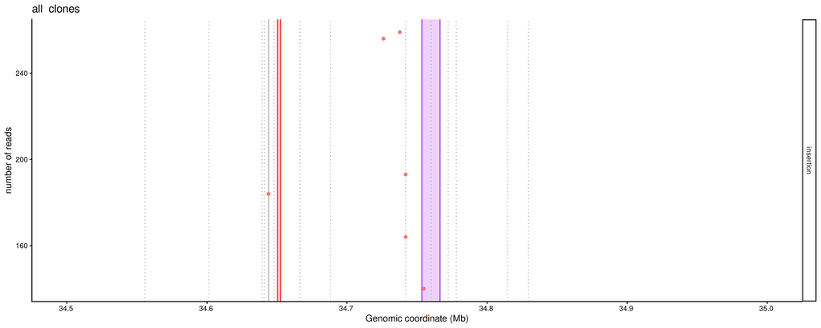

```r
tib_MK03_clones %>%
  filter(start >= prange_zoom[1] & start <= prange_zoom[2]) %>%
  ggplot(aes(x = start, y = read_count, col = cell_line)) +
  facet_grid(expected_clonetype ~.) +
  # annotate enhancer
  annotate("rect", xmin = start(enhancer), xmax = end(enhancer), ymin = -Inf, ymax = Inf, alpha = .2, fill = 'purple') +
  geom_vline(xintercept = c(start(enhancer), end(enhancer)), col = 'purple') +
  # annotate gene
  annotate("rect", xmin = start(gene), xmax = end(gene), ymin = -Inf, ymax = Inf, alpha = .2, fill = 'red') +
  geom_vline(xintercept = c(start(gene), end(gene)), col = 'red') +
  #annotate landing pad
  geom_vline(xintercept = start(landingPad_23), col = 'darkgrey') +
      #annotate CTCF sites
  geom_vline(xintercept = start(CTCF_mm10.chr3), col = 'darkgrey', linetype = 'dotted') +
  #extra CTCF site that is not in the annotation
  geom_vline(xintercept = 34772210, col = 'darkgrey', linetype = "dotted") +

  geom_point() +

  labs(x='Genomic coordinate (Mb)',y='number of reads') +
    #layout:
  theme_classic(base_size = 16) +
  theme(legend.position = "none") +
  scale_x_continuous(breaks = scales::pretty_breaks(n = 6), labels = scales::unit_format(scale = 1E-6, accuracy = 0.1, unit=NULL),
                     limits=prange_zoom) +
  ggtitle("all  clones")
```

# Import corresponding FACS Data

Load matching FACS files

```r
##load the file names
fcs_files_E2259 = dir('/DATA/projects/CTCF_Sox2/Zenodo/FACS_files/export_fcs_R_E2259_MK03_clones/', full.names = T)

#wrangle sample names E2259
names(fcs_files_E2259) = split_string(str_remove(fcs_files_E2259, '.*/'), "_", 2, 9)
flowset_E2259 = flowCore::read.flowSet(files = fcs_files_E2259, alter.names = T, truncate_max_range = F)
flowCore::sampleNames(flowset_E2259) = names(fcs_files_E2259)
pData(flowset_E2259)$name = names(fcs_files_E2259)

pdata_tib_E2259 = pData(flowset_E2259) %>%
  mutate(cell_line = case_when(grepl("23_34A", name) ~ "23_34A",
                               grepl("23_MK3_C1", name) ~ "23_MK03",
                               .default = "unclear"),
         clone_well = case_when(cell_line == "23_34A" ~ str_remove(name, ".*_"),
                                cell_line == "23_MK03" ~ split_string(name, "_", 7)),
         sample = paste0("clone_E2259_", cell_line, "_", clone_well)) %>%
  left_join(tib_MK03_clones) %>%
  data.frame()
rownames(pdata_tib_E2259) = pdata_tib_E2259$name
pData(flowset_E2259) = pdata_tib_E2259

#combine all flowsets together
flowset_fluo =  flowset_E2259 [,c('BL.B..530_30.A', 'YG.D..610_20.A', 'V.F..450_50.A')]
colnames(flowset_fluo) = c("GFP", "mCherry", "mTurq")

#select only the mapped clones (+ctrl sample)
samples_oi = !is.na(pData(flowset_fluo)$chr)

flowset_fluo_selected = flowset_fluo[samples_oi,]
flowCore::sampleNames(flowset_fluo_selected) = pData(flowset_fluo_selected)$sample
```

# Normalizing to MK03 in LP-116kb

## preprocessing

**subtract autofluoresence** When we measured those clones, we didnt measure a non-fluorescent WT mESC control. To adjust for autofluorescence, we used the mean of two WT measurements from another experiment (E2295). The cells were cultured in the same S+L+2i medium and analyzed on the same FACS Fortessa1 machine with the same setup (BL[B] = 470V; YG[D] = 700V; V[F] = 400V; used a 470nm filter instead of 450 for mTurq detection)

mTurq: the mean of two WT measurments mCherry / GFP: the mean of two WT measurments

```r
#manually set autofluorescence values
auto_mTurq = 344
auto_GFP = 479
auto_mCh = 494

#for each fluorophore, subtract the autofluorescence (this data now includes negative fluorescence values, does that matter?)
flowset_fluo_cor = flowCore::transform(flowset_fluo_selected,
                                `GFP_cor` = `GFP` - auto_GFP,
                               `mCherry_cor` = `mCherry` - auto_mCh,
                               `mTurq_cor` = `mTurq` - auto_mTurq)

#get cell count
total_cell_count_tmp = flowCore::keyword(flowset_fluo_cor, "$TOT")[,'$TOT']
total_cell_count = as.numeric(total_cell_count_tmp)
names(total_cell_count) = names(total_cell_count_tmp)

#get median expressions
median_mTurq = sapply(1:length(flowset_fluo_cor), function(i){
  median(exprs(flowset_fluo_cor[[i]])[,'mTurq_cor'])
})
names(median_mTurq) = sampleNames(flowset_fluo_cor)

median_mCherry = sapply(1:length(flowset_fluo_cor), function(i){
  median(exprs(flowset_fluo_cor[[i]])[,'mCherry_cor'])
})
names(median_mCherry) = sampleNames(flowset_fluo_cor)

median_GFP = sapply(1:length(flowset_fluo_cor), function(i){
  median(exprs(flowset_fluo_cor[[i]])[,'GFP_cor'])
})
names(median_GFP) = sampleNames(flowset_fluo_cor)

pData(flowset_fluo_cor)$median_mTurq = median_mTurq
pData(flowset_fluo_cor)$median_mCherry = median_mCherry
pData(flowset_fluo_cor)$median_GFP = median_GFP
pData(flowset_fluo_cor)$total_cell_count = total_cell_count
```

Get summary data

```r
expression_tib_cor = pData(flowset_fluo_cor) %>%
  mutate(mTurq_norm = median_mTurq / median_GFP,
         mCherry_norm = median_mCherry / median_GFP)

clones_by_pos = expression_tib_cor %>%
  group_by(experiment, chr, start, strand, cell_line, expected_clonetype) %>%
  summarize(
    mTurq_mean = mean(median_mTurq),
    mCherry_mean = mean(median_mCherry),
    GFP_mean = mean(median_GFP),
    mTurq_norm_mean = mean(mTurq_norm),
    mCherry_norm_mean = mean(mCherry_norm))
```

## Relative to unhopped 23_MK03 clone

```r
baseline_sample = expression_tib_cor %>%
  dplyr::filter(start == 34643961 & cell_line == "23_MK03") %>%
  group_by(experiment) %>%
  summarize(mTurq_norm_23_MK03 = mean(mTurq_norm),
            mCherry_norm_23_MK03 = mean(mCherry_norm)
            )

expression_tib_cor_rel = left_join(expression_tib_cor, baseline_sample) %>%
    mutate(mTurq_scaled = mTurq_norm / mTurq_norm_23_MK03,
         mCherry_scaled = mCherry_norm / mCherry_norm_23_MK03)

clones_by_pos_rel = expression_tib_cor_rel %>%
  group_by(experiment, chr, start, strand, cell_line, expected_clonetype) %>%
  summarize(
   mTurq_mean = mean(median_mTurq),
    mCherry_mean = mean(median_mCherry),
    GFP_mean = mean(median_GFP),
    mTurq_norm_mean = mean(mTurq_norm),
    mCherry_norm_mean = mean(mCherry_norm),
    mTurq_mean_scaled = mean(mTurq_scaled),
    mCherry_mean_scaled = mean(mCherry_scaled))
```

# Plot mTurq and mCh of sorted MK03 clones

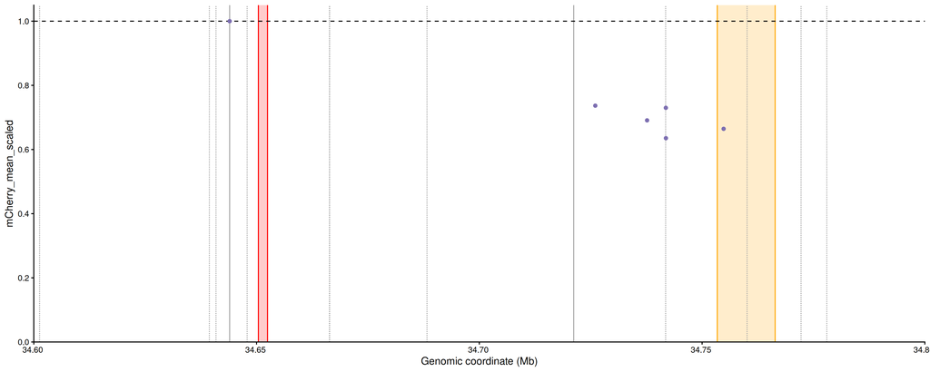

```r
#Plot mCherry insulation
pClones_mapped_norm_MK03_LP116kb_mCherry =
ggplot(dplyr::filter(clones_by_pos_rel, cell_line == "23_MK03"), aes(x = start, y = mCherry_mean_scaled, col = expected_clonetype)) +
  # facet_grid(. ~  experiment, drop=T)+
  # annotate enhancer
  annotate("rect", xmin = start(enhancer), xmax = end(enhancer), ymin = -Inf, ymax = Inf, alpha = .2, fill = 'orange') +
  geom_vline(xintercept = c(start(enhancer), end(enhancer)), col = 'orange') +
  # annotate gene
  annotate("rect", xmin = start(gene), xmax = end(gene), ymin = -Inf, ymax = Inf, alpha = .2, fill = 'red') +
  geom_vline(xintercept = c(start(gene), end(gene)), col = 'red') +
  #annotate landing pad
  geom_vline(xintercept = start(landingPad_23), col = 'darkgrey') +
  geom_vline(xintercept = start(landingPad_8), col = 'darkgrey') +
  #annotate CTCF sites
  geom_vline(xintercept = start(CTCF_mm10.chr3_extra), col = 'darkgrey', lty = '11') +

  #indicate scaled expression of 1 (23_34A)
  geom_hline(yintercept = 1, linetype = 'dashed')+

  #layout
  labs(x='Genomic coordinate (Mb)') +
  theme_classic(base_size = 16) +
  theme(legend.position = "bottom") +
  scale_x_continuous(breaks = scales::pretty_breaks(n = 6),
                     labels = scales::unit_format(scale = 1E-6, accuracy = 0.05, unit=NULL),
                     limits=prange_narrow,
                     expand = c(0,0)
                     ) +
  scale_y_continuous(breaks = scales::pretty_breaks(n = 6),
                     limits=c(0,NA),
                     expand = expansion(mult = c(0,0.05))) +

  #points
  geom_point()+
  scale_color_manual(values  = c(insertion = "#7D6FB1")) +
  theme(legend.position = "none")

pClones_mapped_norm_MK03_LP116kb_mCherry
```

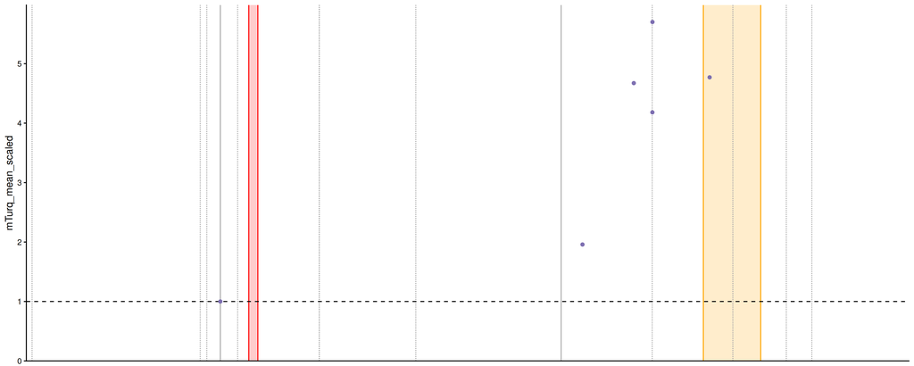

```r
#Plot mTurq
pClones_mapped_norm_MK03_LP116kb_mTurq =
ggplot(dplyr::filter(clones_by_pos_rel, cell_line == "23_MK03"), aes(x = start, y = mTurq_mean_scaled,  col = expected_clonetype)) +
  # facet_grid(. ~  experiment, drop=T)+
  # annotate enhancer
  annotate("rect", xmin = start(enhancer), xmax = end(enhancer), ymin = -Inf, ymax = Inf, alpha = .2, fill = 'orange') +
  geom_vline(xintercept = c(start(enhancer), end(enhancer)), col = 'orange') +
  # annotate gene
  annotate("rect", xmin = start(gene), xmax = end(gene), ymin = -Inf, ymax = Inf, alpha = .2, fill = 'red') +
  geom_vline(xintercept = c(start(gene), end(gene)), col = 'red') +
  #annotate landing pad
  geom_vline(xintercept = start(landingPad_23), col = 'darkgrey') +
  geom_vline(xintercept = start(landingPad_8), col = 'darkgrey') +
  #annotate CTCF sites
  geom_vline(xintercept = start(CTCF_mm10.chr3_extra), col = 'darkgrey', lty = '11') +

  #indicate scaled expression of 1 (23_34A)
  geom_hline(yintercept = 1, linetype = 'dashed')+

  #layout
  #labs(x='Genomic coordinate (Mb)') +
  theme_classic(base_size = 16) +
  scale_x_continuous(breaks = scales::pretty_breaks(n = 6),
                     labels = scales::unit_format(scale = 1E-6, accuracy = 0.05, unit=NULL),
                     limits=prange_narrow,
                     expand = c(0,0)
                     ) +
  scale_y_continuous(breaks = scales::pretty_breaks(n = 6),
                     limits=c(0,NA),
                     expand = expansion(mult = c(0,0.05))) +

  #points
  geom_point()+
  scale_color_manual(values  = c(insertion = "#7D6FB1")) +
  theme(legend.position = "none") +
  theme(axis.title.x=element_blank(),
        axis.text.x=element_blank(),
        axis.ticks.x=element_blank())

pClones_mapped_norm_MK03_LP116kb_mTurq
```

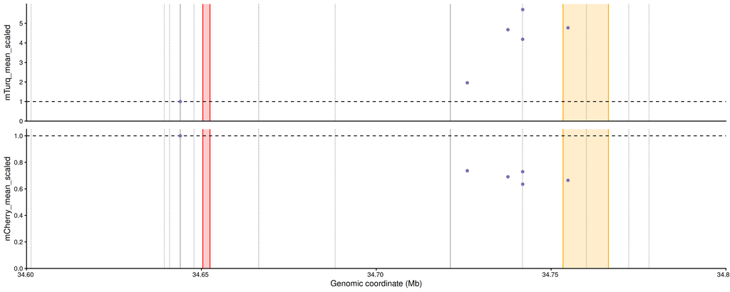

```r
plot_grid(pClones_mapped_norm_MK03_LP116kb_mTurq, pClones_mapped_norm_MK03_LP116kb_mCherry, ncol = 1, align = "v", rel_heights = c(0.75,1))
```

```r
kable(clones_by_pos_rel %>%
        dplyr::filter(cell_line == "23_MK03") %>%
        select(cell_line, strand, expected_clonetype, mTurq_mean_scaled, mCherry_mean_scaled))
```

| experiment | chr | start | cell_line | strand | expected_clonetype | mTurq_mean_scaled | mCherry_mean_scaled |
| --- | --- | --- | --- | --- | --- | --- | --- |
| E2259 | chr3 | 34643961 | 23_MK03 | + | insertion | 1.000000 | 1.0000000 |
| E2259 | chr3 | 34726026 | 23_MK03 | + | insertion | 1.958635 | 0.7366291 |
| E2259 | chr3 | 34737651 | 23_MK03 | + | insertion | 4.673359 | 0.6908938 |
| E2259 | chr3 | 34741864 | 23_MK03 | + | insertion | 4.181399 | 0.7299141 |
| E2259 | chr3 | 34741880 | 23_MK03 | + | insertion | 5.701329 | 0.6353376 |
| E2259 | chr3 | 34754834 | 23_MK03 | + | insertion | 4.770816 | 0.6644631 |